# Lab 8 - Projectile Motion IV: Incorporating Drag

```
    June 21, 2018
```

<< Table of Contents

## P8.1

Modify your projectile motion model from last week to include air resistance. The model should compute the trajectory of a projectile launched from any height, launch angle, and with any initial speed.

```python
import numpy as np
from random import uniform
class Struct: pass

class Drag:
    def __init__(self, A = 0 , p = 1.29, C = 0.1):
        self.value = 0.5 * C * p * A
        self.A, self.p, self.C = A, p, C

    def withUncertainty(self, uncertainty):
        A = uniform(self.A - uncertainty.A, self.A - uncertainty.A)
        p = uniform(self.p - uncertainty.A, self.p - uncertainty.p)
        C = uniform(self.C - uncertainty.A, self.C - uncertainty.C)
        drag = Struct()
        drag.value = 0.5 * C * p * A
        return drag


class Simulator:
    def __init__(self, dt=0.001, gravity = -9.8):
        self.g  = gravity  # m/s^2
        self.dt = dt       # s
        self.last_run = Struct();

    # Euler's Method for running a launch simulation
    # drag and mass optional
    def run(self, angle, velocity, height, drag = Drag(), mass = 1):
        fail_safe = 0;
        a    = angle     # degrees
        v    = velocity  # m/s
        h    = height    # m
        time = [0]       # s
        x    = [0]       # m
        y    = [h]       # m
        vx   = [v * np.cos(np.radians(a))] # m/s
        vy   = [v * np.sin(np.radians(a))] # m/s
        B    = drag.value / mass

        while (y[-1] > 0.0 or vy[-1] > 0.0):
            drag_part = - B * np.sqrt(vx[-1]**2 + vy[-1]**2) * self.dt
            x    .append(x[-1] + vx[-1] * self.dt)
            y    .append(y[-1] + vy[-1] * self.dt)
            vx   .append(vx[-1] + drag_part * vx[-1])
            vy   .append(vy[-1] + drag_part * vy[-1] + self.g * self.dt)
            time .append(time[-1] + self.dt)

            fail_safe += 1
            if fail_safe > 100000: break

        return time, x,y, vy,vy
```

```python
values = Struct()
values.angle    = 45.0  # degrees
values.velocity = 30.0  # m/s
values.gravity  = 9.8   # m/s^2
values.height   = 30   # m
values.mass     = 0.01  # kg
values.area     = np.pi * (0.05**2) # m^2

uncertainty = Struct()
uncertainty.angle    = 1    # degrees
uncertainty.velocity = 0.01 # m/s
uncertainty.gravity  = 0.01 # m/s^2
uncertainty.height   = 0    # m
uncertainty.mass     = 0    # kg
uncertainty.A        = 0    # m^2
uncertainty.C        = 0
uncertainty.p        = 0    # kg/m^3
```

```
Mean of the ranges:              28.74m
Standard deviation of ranges:    0.21
Max velocity in for y direction: 21.57m/s
Max height:                      40.12m
```

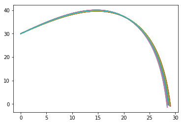

```python
from random import uniform
from matplotlib import pyplot


class Settings:
    def __init__(self, dt = .1, showPlot = True, showHist = True):
        self.dt = dt
        self.showHist = showHist
        self.showPlot = showPlot


def runSimulation (values, uncertainty, drag = Drag(), settings = Settings()):
    num_trials = 100
    ranges = []
    velocities = []
    heights = []

    if settings.showPlot:
        pyplot.figure(1)

    for i in range(num_trials):
        # Get a random numbers from a uniform distribution
        a = uniform(values.angle    - uncertainty.angle,    values.angle    + uncertainty.angle)
        v = uniform(values.velocity - uncertainty.velocity, values.velocity + uncertainty.velocity)
        g = uniform(values.gravity  - uncertainty.gravity,  values.gravity  + uncertainty.gravity)
        h = uniform(values.height   - uncertainty.height,   values.height   + uncertainty.height)

        # run a Euler's Method simulation on the launch
        sim = Simulator(gravity = -g, dt = settings.dt)
        time, x,y, vy,vy = sim.run(a, v, h, mass = values.mass, drag = drag.withUncertainty(uncertainty))

        # plot and record results
        if settings.showPlot: pyplot.plot(x,y)
        ranges.append(x[-1])
        velocities.append(max(max(vy), abs(min(vy))))
        heights.append(max(y))

    print("Mean of the ranges:              {:.2f}m".format(np.mean(ranges)))
    print("Standard deviation of ranges:    {:.2f}".format(np.std(ranges)))
    print("Max velocity in for y direction: {:.2f}m/s".format(max(velocities)))
    print("Max height:                      {:.2f}m".format(max(heights)))
    if settings.showHist:
        pyplot.figure(2)
        pyplot.hist(ranges)

    if settings.showPlot or settings.showHist: pyplot.show()


runSimulation(values, uncertainty, Drag(A = values.area, p = 1.3), Settings(showHist=False))
```

> This matches the expected output as shown in the book

## P8.2

Using a high-speed camera, take a video of the motion. You are free to choose the launch angle and number of clicks on your cannon. Make sure you use the 30 fps setting on the camera. You will need a meter stick (or some other known length) to be in the field of view of your video. Follow the the procedure in the book to extract the trajectory and save it to file.

> Here are our measurements of the ball before we filmed:

```
Weight: 0.2g
Diameter: 0.021m
Launch Angle: 50 degrees
```

##### Click here to download the video of our launch

## P8.3

The two unknown parameters in your Euler’s model are the exit speed and the drag coefficient. To find accurate values for these two paramters you will want to plot the data retrieved from logger pro on top of the predicted trajectory from Euler’s method. You can then vary the exit speed and drag coefficient until the two trajectories overlap.

[output not shown]

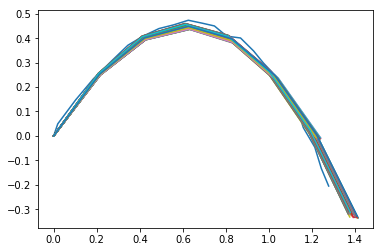

```python
# READ in the logger pro data and parse the file
with open('lab8.csv','r') as f:
    lines = f.readlines()

del lines[0] # Delete the header line
t_logger = [float(n.split(',')[0]) for n in lines]
x_logger = [float(n.split(',')[1]) for n in lines]
y_logger = [float(n.split(',')[2]) for n in lines]
pyplot.plot(x,y)


# establish our approximations and run the simulation to validate the match
values = Struct()
values.angle    = 50.0   # degrees
values.velocity = 3.3    # m/s
values.gravity  = 9.8    # m/s^2
values.height   = 0      # m
values.mass     = 0.0002 # kg
values.area     = np.pi * (0.0105**2) # m^2

uncertainty = Struct()
uncertainty.angle    = 1    # degrees
uncertainty.velocity = 0.01 # m/s
uncertainty.gravity  = 0.01 # m/s^2
uncertainty.height   = 0    # m
uncertainty.mass     = 0    # kg
uncertainty.A        = 0.00001 # m^2
uncertainty.C        = 0.01
uncertainty.p        = 0.1     # kg/m^3


drag = Drag(A = values.area, C = .08)


# run the simulation
runSimulation(values, uncertainty, drag, Settings(dt = .1, showHist=False))
```

> As you can see, an initial speed of $3.3_{\frac{m}{s}}$ and a drag coefficient of $0.08$ give us pretty good results in the simulation.

## P8.4

Now let’s include all relevant uncertainties in your model, similar to what we did last week. You’ll want to make a code that looks similar to last week’s code, with several logical additions for the air drag.

> I already did this form the beginning (see the uncertainty structure in P8.3)

## P8.5

Test your model’s ability to predict the future location of your projectile.

##### (a) Choose some initial conditions(launch angle, launch height) and compute the projectile’s trajectory. These condidtion should be different from the conditions when you recorded the video.

# I WAS UNABLE TO COMPLETE THIS PART BECAUSE I RAN OUT OF TIME

# Take Home Thought

Our program is becoming more complex. It now accounts for air drag. I am glad we are not doing this all by hand, and instead are taking complete advangate of the advanced features that Computer Science can offer.

# Signing Off

- Kyle West
- Landon Lewis